# Diversitree_Likelihood

Sergei Tarasov

2025-06-26

```r
library(diversitree)
library(plyr)
library(expm)
```

# Mk Model

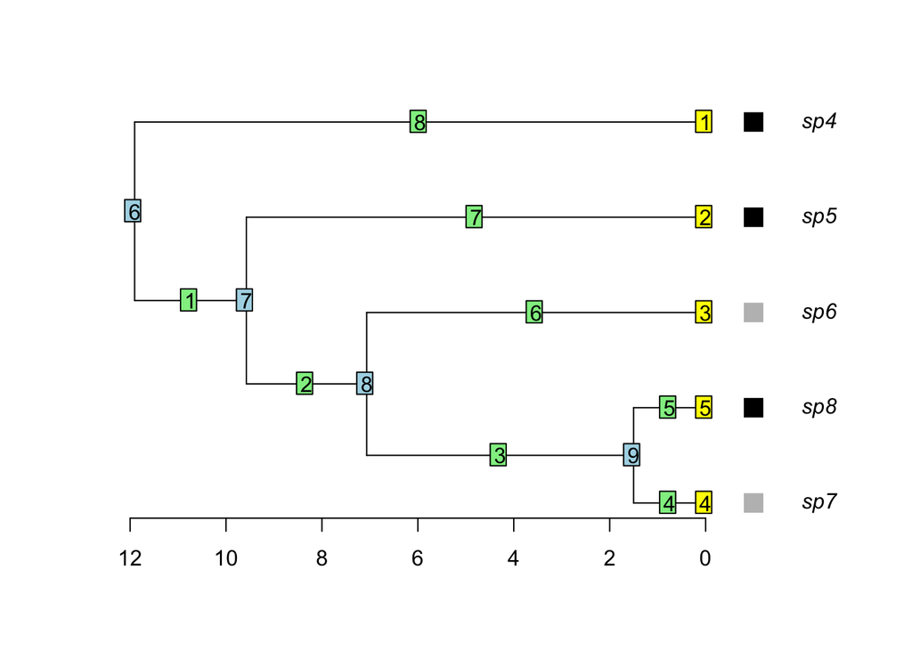

```r
# Read in tree and Plot
phy <- readRDS('asr/tree.rds')
cols <- mapvalues(phy$tip.state, from = c(0, 1), to=c("grey", 'black'))
plot(phy, label.offset = 2, cex=1, no.margin = F)
tiplabels(pch = 15, col = cols, cex = 2, adj = 1.5)
nodelabels()
tiplabels()
edgelabels()
axisPhylo()
```

```r
# define Ln function
lik.mk <- make.mk2(phy, phy$tip.state, strict=T)
# estimate Ln given pars
pars.mk <- c(.1, .2)
lik.mk.est <- lik.mk(pars.mk, root=ROOT.FLAT, intermediates = T)
print(lik.mk.est)
```

```
#> [1] -4.607403
#> attr(,"intermediates")
#> attr(,"intermediates")$init
#>      [,1] [,2] [,3] [,4] [,5]      [,6]      [,7]      [,8]      [,9]
#> [1,]   NA   NA   NA   NA   NA 0.2318593 0.2335648 0.2584504 0.1078769
#> [2,]   NA   NA   NA   NA   NA 0.2688127 0.2656825 0.2390440 0.1860757
#>
#> attr(,"intermediates")$base
#>           [,1]      [,2]      [,3]      [,4]      [,5] [,6]     [,7]      [,8]
#> [1,] 0.4792106 0.4587568 0.5464041 0.7842463 0.1375548   NA 0.483836 0.5091255
#> [2,] 0.5207894 0.5412432 0.4535959 0.2157537 0.8624452   NA 0.516164 0.4908745
#>           [,9]
#> [1,] 0.4730023
#> [2,] 0.5269977
#>
#> attr(,"intermediates")$lq
#> [1] -0.3915086 -0.3775845  0.2572149  0.1141511 -0.1288811  0.0000000 -0.7054966
#> [8] -0.6913172 -1.2990303
#>
#> attr(,"intermediates")$vals
#> [1] 0.2318593 0.2688127
#>
#> attr(,"intermediates")$pij
#>           [,1]      [,2]      [,3]      [,4]      [,5] [,6]      [,7]      [,8]
#> [1,] 0.6760362 0.6855152 0.7066770 0.8790785 0.8790785   NA 0.8323659 0.8236975
#> [2,] 0.6479275 0.6289695 0.5866459 0.2418430 0.2418430   NA 0.3352683 0.3526051
#> [3,] 0.3239638 0.3144848 0.2933230 0.1209215 0.1209215   NA 0.1676341 0.1763025
#> [4,] 0.3520725 0.3710305 0.4133541 0.7581570 0.7581570   NA 0.6647317 0.6473949
#>           [,9]
#> [1,] 0.7294541
#> [2,] 0.5410919
#> [3,] 0.2705459
#> [4,] 0.4589081
#>
#> attr(,"intermediates")$root.p
#> [1] 0.5
#>
#> attr(,"vals")
#> [1] 0.2318593 0.2688127
```

## Definitions of lik.mk() object

- **`init`**: Variable values at the **tip** of each branch. Note: it seems like there a bug for tips printing NAs. The computations do work. When Probs of two sister branches are combined at a node, it’s an init variable of a downstream brahnch
- **`base`**: Variable values at the **base** of each branch. Note: they are normalized, see below.
- **`lq`**: The **compensation factor** for each branch.  
  Recall that the compensation factor is the **log of the sum** of the variables at the base of each branch.
- **`pij`**: Are present only in Mk model. They are direct probs after exponentiation.
- **`root.p`**: is the root prior.
- **`vals`**: is the variables at the root node, they are the same **`init`** for node 6.

## Manual calculations

### Along branches

Let’s consider sp8 and sp7 tips (branches 4 and 5) and go downstream to see how it works.

```r
Q <- matrix(c(-0.1,0.1,
              0.2, -0.2), 2, 2, byrow=T)
print(Q)
```

```
#>      [,1] [,2]
#> [1,] -0.1  0.1
#> [2,]  0.2 -0.2
```

```r
# branch length
br5 <- phy$edge.length[5]
# Probability
P5 <- expm(Q*br5) %*% c(0,1)
# compensation factor for branch 5
lq5 <- log(sum(P5))
# Normalized Probs at the base of the branch 5
base5 <- P5/sum(P5)

print(lq5)
```

```
#> [1] -0.1288811
```

```r
print(base5)
```

```
#>           [,1]
#> [1,] 0.1375548
#> [2,] 0.8624452
```

```r
print(attr(lik.mk.est, "intermediates")$lq[5])
```

```
#> [1] -0.1288811
```

```r
print(attr(lik.mk.est, "intermediates")$base[,5])
```

```
#> [1] 0.1375548 0.8624452
```

```r
# Note, the following vars are equal
log(P5) == log(base5) + lq5
```

```
#>      [,1]
#> [1,] TRUE
#> [2,] TRUE
```

Branch 4.

```r
br4 <- phy$edge.length[4]
P4 <- expm(Q*br4) %*% c(1,0)
lq4 <- log(sum(P4))
base4 <- P4/sum(P4)

print(lq4)
```

```
#> [1] 0.1141511
```

```r
print(base4)
```

```
#>           [,1]
#> [1,] 0.7842463
#> [2,] 0.2157537
```

```r
print(attr(lik.mk.est, "intermediates")$lq[4])
```

```
#> [1] 0.1141511
```

```r
print(attr(lik.mk.est, "intermediates")$base[,4])
```

```
#> [1] 0.7842463 0.2157537
```

Branch 9: the ancestor of Branch 4 and Branch 5.

```r
# init array for branch 9: combining two bases
init9 <- base5*base4

# branch 9 length: note id differs from ape
br9 <- phy$edge.length[3]
# Now Probs are condition on init9, note it's normalized
P9 <- expm(Q*br9) %*% init9
lq9 <- log(sum(P9))
base9 <- P9/sum(P9)

print(init9)
```

```
#>           [,1]
#> [1,] 0.1078769
#> [2,] 0.1860757
```

```r
print(lq9)
```

```
#> [1] -1.29903
```

```r
print(base9)
```

```
#>           [,1]
#> [1,] 0.4730023
#> [2,] 0.5269977
```

```r
print(attr(lik.mk.est, "intermediates")$init[,9])
```

```
#> [1] 0.1078769 0.1860757
```

```r
print(attr(lik.mk.est, "intermediates")$lq[9])
```

```
#> [1] -1.29903
```

```r
print(attr(lik.mk.est, "intermediates")$base[,9])
```

```
#> [1] 0.4730023 0.5269977
```

### At the root

```r
# Root vals at node 6.
root.vals <- attr(lik.mk.est, "intermediates")$vals
root.pi <- c(0.5, 0.5)
LQ <- attr(lik.mk.est, "intermediates")$lq

# Likelihood Manual
log(sum(root.vals * root.pi)) + sum(LQ)
```

```
#> [1] -4.607403
```

```r
# Likelihood diversitree
print(lik.mk.est[1])
```

```
#> [1] -4.607403
```

# BiSSE Model

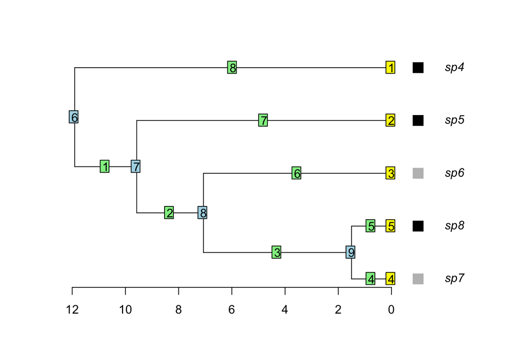

```r
# Read in tree and Plot
phy <- readRDS('asr/tree.rds')
cols <- mapvalues(phy$tip.state, from = c(0, 1), to=c("grey", 'black'))
plot(phy, label.offset = 2, cex=1, no.margin = F)
tiplabels(pch = 15, col = cols, cex = 2, adj = 1.5)
nodelabels()
tiplabels()
edgelabels()
axisPhylo()
```

## Make Ln functions

```r
lik <- make.bisse(phy, phy$tip.state)
pars <- c(.1, .2, .03, .06, .01, .02)
lik.est <- lik(pars, root=ROOT.FLAT, intermediates=T)
print(lik.est)
```

```
#> [1] -18.50517
#> attr(,"intermediates")
#> attr(,"intermediates")$init
#>      [,1] [,2] [,3] [,4] [,5]        [,6]        [,7]       [,8]        [,9]
#> [1,]    0    0    0    0    0 0.198899482 0.176406551 0.14577813 0.041278941
#> [2,]    0    0    0    0    0 0.252231745 0.235196229 0.20800511 0.074677254
#> [3,]    0    0    1    1    0 0.003889247 0.009851977 0.03283898 0.001581733
#> [4,]    1    1    0    0    1 0.128102366 0.043663283 0.01186877 0.005245716
#>
#> attr(,"intermediates")$base
#>           [,1]      [,2]       [,3]       [,4]       [,5] [,6]      [,7]
#> [1,] 0.1988995 0.1764066 0.14577813 0.04127894 0.04127894   NA 0.1988995
#> [2,] 0.2522317 0.2351962 0.20800511 0.07467725 0.07467725   NA 0.2522317
#> [3,] 0.1711848 0.1316058 0.90697408 0.97333815 0.01625060   NA 0.2271959
#> [4,] 0.8288152 0.8683942 0.09302592 0.02666185 0.98374940   NA 0.7728041
#>           [,8]      [,9]
#> [1,] 0.1764066 0.1457781
#> [2,] 0.2351962 0.2080051
#> [3,] 0.7485976 0.3620719
#> [4,] 0.2514024 0.6379281
#>
#> attr(,"intermediates")$lq
#> [1] -2.3079058 -1.9381048 -0.7714612 -0.1766689 -0.3800975  0.0000000 -3.2862093
#> [8] -3.3879660 -5.9689676
#>
#> attr(,"intermediates")$vals
#> [1] 0.198899482 0.252231745 0.003889247 0.128102366
#>
#> attr(,"intermediates")$root.p
#> [1] 0.5
#>
#> attr(,"vals")
#> [1] 0.198899482 0.252231745 0.003889247 0.128102366
```

Now, extracting various functions for Ln estimation from lik().

```r
e <- environment(lik)
# Ln for all branches f
all_branches <- e$all_branches
# root f
rootfunc <- e$rootfunc


eb <- environment(e$all_branches)
# Ln along single branch f
branches <- eb$branches
# Ln at a node f
initial.conditions <- eb$initial.conditions
```

### branches() and initial.conditions()

1. branches(): along a branch
2. initial.conditions(): at node

```r
#------ branches (y, len, pars, t0, idx)
#
# in do.asr.marginal.R():
# branches(y.in, len[i], pars, depth[i], i)
# for depth[i], i, I herein use zeros but it may differ in td models

# Branch 5, sp8 (black)
br5 <- phy$edge.length[5]
y5 <- c(0,0,0, 1)
base5.raw <- branches(y5, br5, pars, 0, 0)

# first is lq, second is base
print(base5.raw)
```

```
#> [[1]]
#> [1] -0.3800975
#>
#> [[2]]
#>            [,1]
#> [1,] 0.04127894
#> [2,] 0.07467725
#> [3,] 0.01625060
#> [4,] 0.98374940
```

```r
attr(lik.est, "intermediates")$lq[5]
```

```
#> [1] -0.3800975
```

```r
attr(lik.est, "intermediates")$base[,5]
```

```
#> [1] 0.04127894 0.07467725 0.01625060 0.98374940
```

```r
# Branch 4, sp7 (white)
br4 <- phy$edge.length[4]
y4 <- c(0,0, 1,0)
base4.raw <- branches(y4, br4, pars, 0, 0)
print(base4.raw)
```

```
#> [[1]]
#> [1] -0.1766689
#>
#> [[2]]
#>            [,1]
#> [1,] 0.04127894
#> [2,] 0.07467725
#> [3,] 0.97333815
#> [4,] 0.02666185
```

```r
#------ initial.conditions(init, pars, t, idx)
#
# in do.asr.marginal.R():
# initial.conditions(branch.base[,children[j,]],  pars, depth[j], j)

# At node 9
base4_5 <- cbind(base4.raw[[2]], base5.raw[[2]])
init9 <- initial.conditions(base4_5, pars, 0, 0)

print(init9)
```

```
#> [1] 0.041278941 0.074677254 0.001581733 0.005245716
```

```r
attr(lik.est, "intermediates")$init[,9]
```

```
#> [1] 0.041278941 0.074677254 0.001581733 0.005245716
```

### At root

```r
#
# rootfunc(res, pars, condition.surv, root, root.p, intermediates)
vals <- attr(lik.est, "intermediates")$vals
LQ <- attr(lik.est, "intermediates")$lq
res <- list(vals=vals, lq=LQ)

Ln <- rootfunc(res, pars, condition.surv=T, root=ROOT.FLAT, root.p=NULL, intermediates=F)

print(Ln)
```

```
#> [1] -18.50517
```

```r
print(lik.est[[1]])
```

```
#> [1] -18.50517
```